# Análise de Regressão: Sono em Mamiferos

# LASSO

É considerado um método mais moderno e robusto para fazer seleção de variáveis, especialmente quando temos multicolinearidade. Além disso, esse método funciona penalizando os coeficientes, utilizando um certo *alpha*. Para escolher o melhor parâmetro, utilizamos **Validação Cruzada**.

Relembrando LASSO: A Regressão LASSO (Least Absolute Shrinkage and Selection Operator) é uma das técnicas de penalização mais populares. Ela encolhe os coeficientes das variáveis menos importantes em direção a zero. a característica especial do LASSO é que, para um 𝜆suficientemente grande, ele pode encolher os coeficientes de algumas variáveis exatamente para zero, realizando assim a seleção de variáveis de forma automática. Ela minimiza a soma dos quadrados dos erros (como na regressão usual), mas com uma restrição adicional:

$$\min_{\beta_0, \beta_1, \ldots, \beta_k} \left\{ \sum_{i=1}^{n}
\left(y_i - \beta_0 - \sum_{j=1}^{k} x_{ij}\beta_j\right)^2 + \lambda
\sum_{j=1}^{k} |\beta_j| \right\}$$
O parâmetro de penalidade 𝜆 controla a força do encolhimento.

```r
library(glmnet)
```

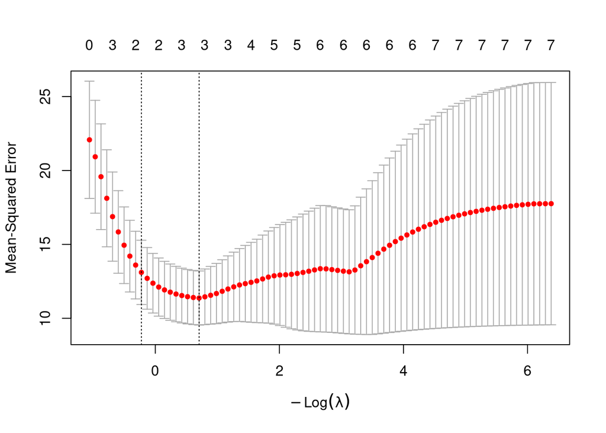

```r
# 2. Preparar os dados para o glmnet
# Ele não aceita a fórmula "Y ~ X", ele quer Matrizes
# Criamos a matriz de preditores (X)
x <- model.matrix(total_sleep ~ body_wt + brain_wt + life_span +
                     gestation + predation + exposure + danger,
                   data = mammals_clean)[, -1] # [, -1] remove o "intercept"

y <- mammals_clean$total_sleep

# 3. Rodar o LASSO (usando Cross-Validation para achar o 'lambda' ideal)
# alpha = 1 significa LASSO (alpha = 0 seria Ridge)
cv_lasso <- cv.glmnet(x, y, alpha = 1)
plot(cv_lasso)
```

```r
# 4. Ver os resultados
print("--- Coeficientes do Modelo LASSO ---")
```

```
## [1] "--- Coeficientes do Modelo LASSO ---"
```

```r
# Ver os coeficientes no "lambda" (penalidade) ideal
coef(cv_lasso, s = "lambda.min")
```

```
## 8 x 1 sparse Matrix of class "dgCMatrix"
##               lambda.min
## (Intercept) 16.064819425
## body_wt      .
## brain_wt     .
## life_span   -0.007210917
## gestation   -0.013655310
## predation    .
## exposure     .
## danger      -1.303820876
```

```r
print(cv_lasso$lambda.min)
```

```
## [1] 0.4936275
```

```r
model_final_lasso <- lm(total_sleep ~ gestation + danger,
                        data = mammals_clean)
vif(model_final_lasso)
```

```
## gestation    danger
##  1.103485  1.103485
```

```r
summary(model_final_lasso)
```

```
##
## Call:
## lm(formula = total_sleep ~ gestation + danger, data = mammals_clean)
##
## Residuals:
##     Min      1Q  Median      3Q     Max
## -6.4119 -2.7960 -0.1808  2.5050  5.4569
##
## Coefficients:
##             Estimate Std. Error t value Pr(>|t|)
## (Intercept) 17.10323    1.09983  15.551  < 2e-16 ***
## gestation   -0.01746    0.00407  -4.289 0.000114 ***
## danger      -1.55814    0.37486  -4.157 0.000171 ***
## ---
## Signif. codes:  0 '***' 0.001 '**' 0.01 '*' 0.05 '.' 0.1 ' ' 1
##
## Residual standard error: 3.171 on 39 degrees of freedom
## Multiple R-squared:  0.5687, Adjusted R-squared:  0.5465
## F-statistic: 25.71 on 2 and 39 DF,  p-value: 7.567e-08
```

# Conclusão LASSO

```r
model_final <- model_final_lasso
```

# Análise de Resíduos

A análise de resíduos é essencial para verificar se o modelo linear ajustado atende aos pressupostos clássicos da regressão: normalidade dos erros, homocedasticidade, independência e ausência de padrões sistemáticos.

# Normal QQ-plot dos Resíduos

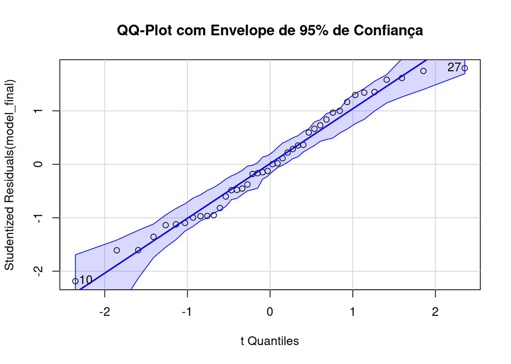

```
## [1] 10 27
```

```r
qqPlot(model_final,
       envelope = 0.95,
       main = "QQ-Plot com Envelope de 95% de Confiança")
```

```r
shapiro.test(residuals(model_final)) # p-valor > 0.05
```

```
##
##  Shapiro-Wilk normality test
##
## data:  residuals(model_final)
## W = 0.97228, p-value = 0.3927
```

Tendo esses dados em mente, podemos assumir que os erros seguem uma distribuição Normal.

# Autocorrelação entre os erros - Teste de Durbin-Watson

```r
car::durbinWatsonTest(model_final, max.lag = 1)
```

```
##  lag Autocorrelation D-W Statistic p-value
##    1       0.2955876      1.336584   0.036
##  Alternative hypothesis: rho != 0
```

Como o p-valor é menor do que 0.05, rejeitamos H0 e supomos que há correlação entre os erros, mas não muito forte pois a estatística de teste D está próxima de 2.

Relembrando: • 𝐷 ≈ 2: Não há autocorrelação. • 𝐷 ≈ 0: Autocorrelação positiva. • 𝐷 ≈ 4: Autocorrelação negativa.

# Resíduos VS Valores Ajustados

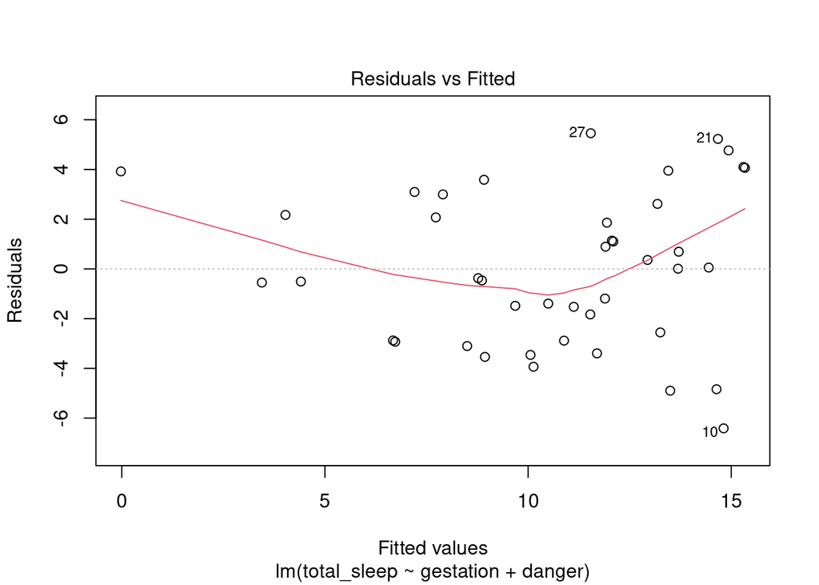

```r
par(mfrow = c(1,1))
plot(model_final, which = 1)
```

A linha forma uma curva. → existe não-linearidade → o modelo linear não está capturando bem a relação.

A largura dos pontos varia ao longo da linha horizontal em y=0. → há indícios de heterocedasticidade.

# Teste de Heterocedasticidade (Breusch-Pagan)

```r
install.packages("lmtest")
library(lmtest)
bptest(model_final)
```

```
##
##  studentized Breusch-Pagan test
##
## data:  model_final
## BP = 9.0782, df = 2, p-value = 0.01068
```

O p-valor é menor do que 0.05 , então a um nível de 5% de significância rejeitamos H0 e consideramos que o modelo apresenta heterocedasticidade.

Tendo esses resultados em mente, o ideal é fazermos uma transformação de variáveis.

Uma medida corretiva comum para a não-normalidade e/ou variância não-constante é transformar a variável resposta Y, criando uma nova variável Y*.

# Transformação de Box-Cox

```r
install.packages("MASS")
library(MASS)
```

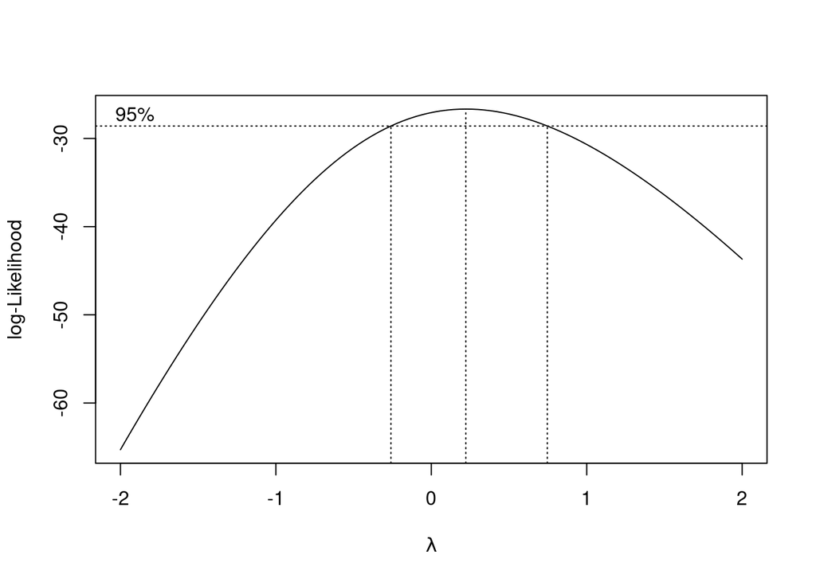

```r
#Achando o lambda ideal
box <- boxcox(model_final, plotit = TRUE)
```

```r
lambda <- box$x[which.max(box$y)]
lambda
```

```
## [1] 0.2222222
```

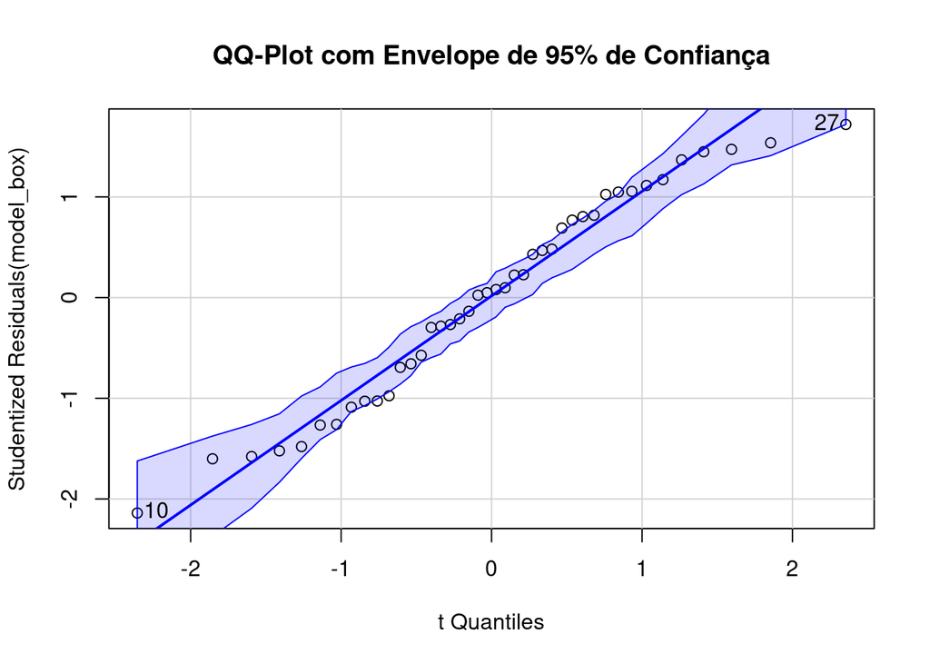

```
## [1] 10 27
```

```r
#Transformar y:
if (abs(lambda) < 1e-6) {
  y_trans <- log(mammals_clean$total_sleep)
} else {
  y_trans <- (mammals_clean$total_sleep^lambda - 1)/lambda
}

#verificar se o modelo está melhor
model_box <- lm(y_trans ~ gestation + danger, data = mammals_clean)
qqPlot(model_box,
       envelope = 0.95,
       main = "QQ-Plot com Envelope de 95% de Confiança")
```

```r
bptest(model_box)
```

```
##
##  studentized Breusch-Pagan test
##
## data:  model_box
## BP = 1.1857, df = 2, p-value = 0.5528
```

```r
dwtest(model_box)
```

```
##
##  Durbin-Watson test
##
## data:  model_box
## DW = 1.329, p-value = 0.01311
## alternative hypothesis: true autocorrelation is greater than 0
```

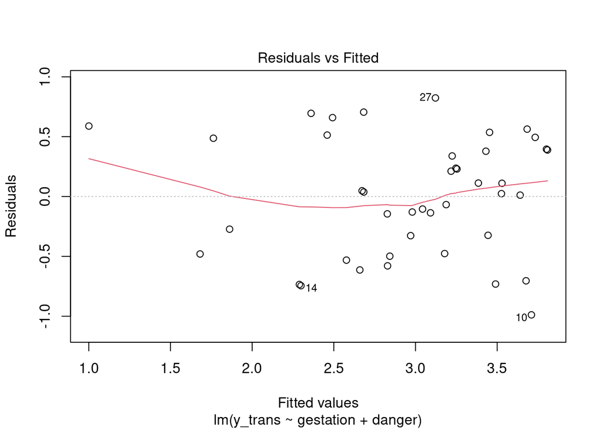

```r
par(mfrow = c(1,1))
plot(model_box, which = 1)
```

```r
shapiro.test(residuals(model_box)) # p-valor > 0.05
```

```
##
##  Shapiro-Wilk normality test
##
## data:  residuals(model_box)
## W = 0.96113, p-value = 0.1621
```

# Conclusão Geral da Transformação Box-Cox

Heterocedasticidade: RESOLVIDA

Normalidade: ERROS CONTINUAM SEGUINDO DISTRIBUIÇÃO NORMAL

(Transformação Box–Cox ajudou)

Autocorrelação dos resíduos: AINDA PRESENTE